# Comparación ENB->LNB

BioScienceApps

Estefania Mancini

18-21 de abril de 2022

# Detección de genes diferencialmente expresados

Cargamos todas los paquetes que usaremos:

```r
library(ggplot2)
library(reshape2)
library(edgeR)
library(ggrepel)
library(org.Mm.eg.db)
```

Cargaremos la tabla de counts a nivel gen

```r
counts <-
    read.table(
        "/home/alumno01/data/mouse/geneCountsMmu.tab",
        row.names = 1,
        header = T,
        stringsAsFactors = F
    )
```

Para explorar un poco la tabla de datos, miremos algunas medidas resumen y la distribucion de los counts:

```r
class(counts)
```

```
## [1] "data.frame"
```

```r
dim(counts)
```

```
## [1] 38924     9
```

```r
head(counts)
```

```
##                    ENB_1 ENB_2 ENB_3 LNB_1 LNB_2 LNB_3 NSC_1 NSC_2 NSC_3
## ENSMUSG00000090025     0     0     0     0     0     0     0     0     0
## ENSMUSG00000064842     0     0     0     0     0     0     0     0     0
## ENSMUSG00000051951    92    27    21    70   130     0    11    60    16
## ENSMUSG00000089699    11     4     7     2     8     0     0     0     0
## ENSMUSG00000088333     0     0     0     0     0     0     0     0     0
## ENSMUSG00000025900     0     0     0     0     0     0     0     0     0
```

```r
summary(counts)
```

```
##      ENB_1              ENB_2             ENB_3              LNB_1
##  Min.   :     0.0   Min.   :    0.0   Min.   :     0.0   Min.   :    0.0
##  1st Qu.:     0.0   1st Qu.:    0.0   1st Qu.:     0.0   1st Qu.:    0.0
##  Median :     0.0   Median :    0.0   Median :     0.0   Median :    0.0
##  Mean   :   206.6   Mean   :  126.8   Mean   :   256.7   Mean   :  134.8
##  3rd Qu.:    64.0   3rd Qu.:   43.0   3rd Qu.:    85.0   3rd Qu.:   60.0
##  Max.   :921527.0   Max.   :50312.0   Max.   :626510.0   Max.   :76274.0
##      LNB_2              LNB_3              NSC_1             NSC_2
##  Min.   :     0.0   Min.   :    0.00   Min.   :    0.0   Min.   :     0.0
##  1st Qu.:     0.0   1st Qu.:    0.00   1st Qu.:    0.0   1st Qu.:     0.0
##  Median :     0.0   Median :    0.00   Median :    0.0   Median :     0.0
##  Mean   :   234.7   Mean   :   99.14   Mean   :  244.8   Mean   :   222.8
##  3rd Qu.:    84.0   3rd Qu.:   45.00   3rd Qu.:  121.0   3rd Qu.:    96.0
##  Max.   :539477.0   Max.   :73152.00   Max.   :69142.0   Max.   :830771.0
##      NSC_3
##  Min.   :    0.0
##  1st Qu.:    0.0
##  Median :    0.0
##  Mean   :  201.4
##  3rd Qu.:  102.0
##  Max.   :60275.0
```

El primer paso entonces es subsetear la tabla y la podemos reordenar ya de acuerdo a las condiciones a comparar (por practicidad):

```r
dataset2<-counts[,c(1,2,3,4,5,6)]
head(dataset2)
```

```
##                    ENB_1 ENB_2 ENB_3 LNB_1 LNB_2 LNB_3
## ENSMUSG00000090025     0     0     0     0     0     0
## ENSMUSG00000064842     0     0     0     0     0     0
## ENSMUSG00000051951    92    27    21    70   130     0
## ENSMUSG00000089699    11     4     7     2     8     0
## ENSMUSG00000088333     0     0     0     0     0     0
## ENSMUSG00000025900     0     0     0     0     0     0
```

Podemos explorar usando boxplots como es la distribución de los counts en las diferentes muestras:

```r
df<- melt(dataset2)
```

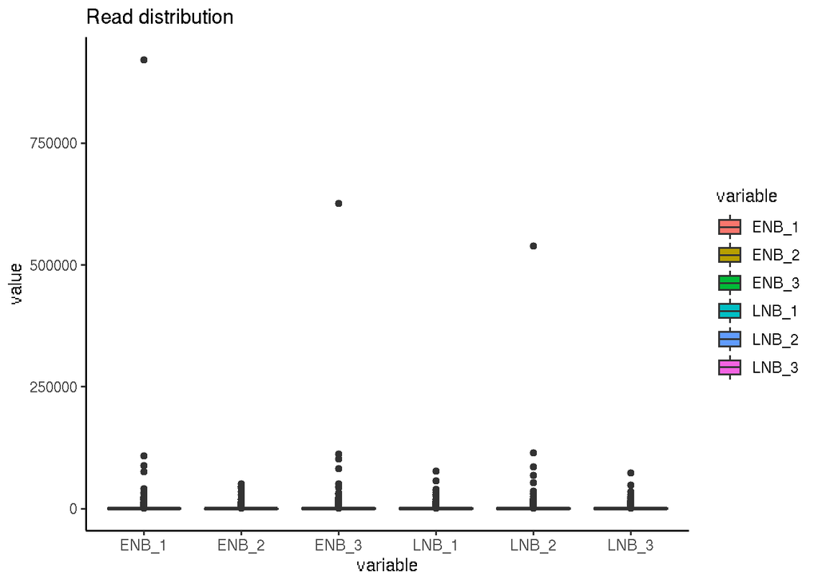

```r
ggplot(df, aes(x=variable, y=value, fill=variable)) +
  geom_boxplot()+
  theme_classic()+
  labs(title="Read distribution")
```

- Para comenzar a trabajar creamos un objeto de tipo **DGELis**t que es propio del paquete **edgeR**. tenemos que pasarle los conteos y un vector factorial con las condiciones de cada muestra.

```r
condition<-factor(rep(c("ENB","LNB"), each=3))
levels(condition)
```

```
## [1] "ENB" "LNB"
```

- Cuidado acá porque el vector condition tiene que ser factorial y hay que definir el orden de los factores a mano (por defecto se ordenarán alfabéticamente)

Para cambiarlo:

```r
condition<-factor(rep(c("ENB","LNB"), each=3),
                  levels = c("ENB","LNB"))
levels(condition)
```

```
## [1] "ENB" "LNB"
```

Para comprobar que el contraste que analizaremos está en el orden correcto, usaremos la función **model.matrix** (la veremos en la práctica más avanzada)

```r
design <- model.matrix(~ condition)
design
```

```
##   (Intercept) conditionLNB
## 1           1            0
## 2           1            0
## 3           1            0
## 4           1            1
## 5           1            1
## 6           1            1
## attr(,"assign")
## [1] 0 1
## attr(,"contrasts")
## attr(,"contrasts")$condition
## [1] "contr.treatment"
```

```r
y <- DGEList(counts=dataset2, group=condition)
keep <- filterByExpr(y)
summary(keep)
```

```
##    Mode   FALSE    TRUE
## logical   25597   13327
```

```r
y <- y[keep, , keep.lib.sizes=FALSE]
condition
```

```
## [1] ENB ENB ENB LNB LNB LNB
## Levels: ENB LNB
```

## Estimación de los factores de normalización

```r
y <- calcNormFactors(y)
y
```

```
## An object of class "DGEList"
## $counts
##                    ENB_1 ENB_2 ENB_3 LNB_1 LNB_2 LNB_3
## ENSMUSG00000051951    92    27    21    70   130     0
## ENSMUSG00000033845   534   378   602   440   664   193
## ENSMUSG00000025903   255   150   291   198   268   128
## ENSMUSG00000033813   335   185   353   235   381   180
## ENSMUSG00000062588    58    37    73    21    78    11
## 13322 more rows ...
##
## $samples
##       group lib.size norm.factors
## ENB_1   ENB  8019411    0.9442179
## ENB_2   ENB  4921223    1.0543567
## ENB_3   ENB  9963571    1.0053376
## LNB_1   LNB  5217595    1.0213988
## LNB_2   LNB  9098721    1.0304272
## LNB_3   LNB  3826265    0.9493265
```

## Relación entre réplicas

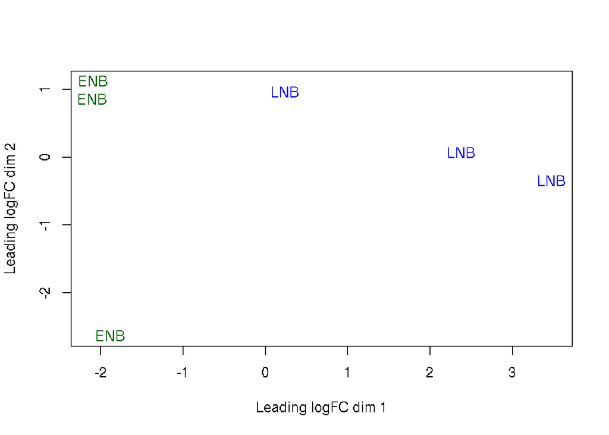

```r
plotMDS(y, labels=condition,
col=c("darkgreen","blue")[factor(condition)])
```

## Dispersión

```r
y <- estimateDisp(y, verbose=TRUE)
```

```
## Using classic mode.
```

```r
y$common.dispersion
```

```
## [1] 0.2498206
```

```r
sqrt(y$common.dispersion)
```

```
## [1] 0.4998205
```

```r
summary(y$trended.dispersion)
```

```
##    Min. 1st Qu.  Median    Mean 3rd Qu.    Max.
## 0.08601 0.10649 0.18759 0.28932 0.43050 0.77296
```

```r
summary(y$tagwise.dispersion)
```

```
##    Min. 1st Qu.  Median    Mean 3rd Qu.    Max.
## 0.04272 0.08577 0.16249 0.30720 0.37468 3.49933
```

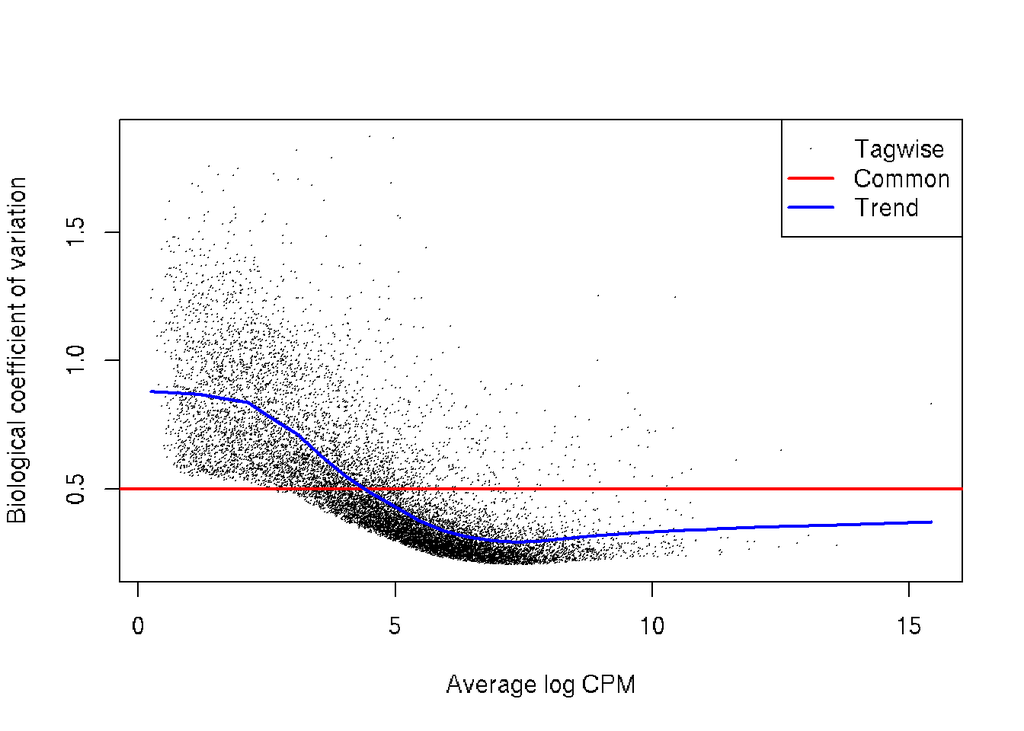

```r
plotBCV(y)
```

# Expresión diferencial

```r
de<-exactTest(y)
str(de)
```

```
## Formal class 'DGEExact' [package "edgeR"] with 1 slot
##   ..@ .Data:List of 3
##   .. ..$ :'data.frame':  13327 obs. of  3 variables:
##   .. .. ..$ logFC : num [1:13327] 0.479 0.0245 0.1373 0.2194 -0.506 ...
##   .. .. ..$ logCPM: num [1:13327] 3.02 6.1 5.02 5.39 2.72 ...
##   .. .. ..$ PValue: num [1:13327] 0.719 0.944 0.709 0.515 0.466 ...
##   .. ..$ : chr [1:2] "ENB" "LNB"
##   .. ..$ : NULL
```

```r
head(de)
```

```
## An object of class "DGEExact"
## $table
##                          logFC   logCPM    PValue
## ENSMUSG00000051951  0.47902586 3.018266 0.7192421
## ENSMUSG00000033845  0.02449704 6.100815 0.9437310
## ENSMUSG00000025903  0.13727823 5.017010 0.7094129
## ENSMUSG00000033813  0.21940132 5.386972 0.5154440
## ENSMUSG00000062588 -0.50604948 2.717074 0.4660793
## ENSMUSG00000002459  0.51777784 4.780407 0.4478587
##
## $comparison
## [1] "ENB" "LNB"
```

```r
tt <- topTags(de)
tt
```

```
## Comparison of groups:  LNB-ENB
##                        logFC   logCPM       PValue          FDR
## ENSMUSG00000020808 -3.307172 6.397367 3.453675e-28 4.602713e-24
## ENSMUSG00000006398 -3.750490 7.016683 2.781374e-27 1.853368e-23
## ENSMUSG00000017716 -3.289403 6.450697 1.398545e-24 6.212803e-21
## ENSMUSG00000046295 -5.658824 5.426985 4.595531e-23 1.531116e-19
## ENSMUSG00000012443 -3.185382 6.769140 8.060529e-22 2.148453e-18
## ENSMUSG00000040204 -3.477840 6.850909 7.861722e-21 1.746220e-17
## ENSMUSG00000062248 -3.066923 5.794657 7.715758e-20 1.468970e-16
## ENSMUSG00000054717 -3.143312 8.735422 1.734777e-19 2.889922e-16
## ENSMUSG00000026605 -3.450655 7.330113 1.983981e-19 2.937835e-16
## ENSMUSG00000019942 -3.349684 6.491488 1.160076e-18 1.546033e-15
```

```r
tt <- topTags(de, n = nrow(de))
```

*¿Cuáles son los genes que están más afectado en este experimento? ¿Tiene lógica?*

Podemos explorar rápidamente cómo se distribuyeron los *pvalues*:

```r
summary(tt$table$FDR)
```

```
##    Min. 1st Qu.  Median    Mean 3rd Qu.    Max.
##  0.0000  0.3908  0.7190  0.6246  0.8957  1.0000
```

```r
table(tt$table$FDR <0.05)
```

```
##
## FALSE  TRUE
## 12157  1170
```

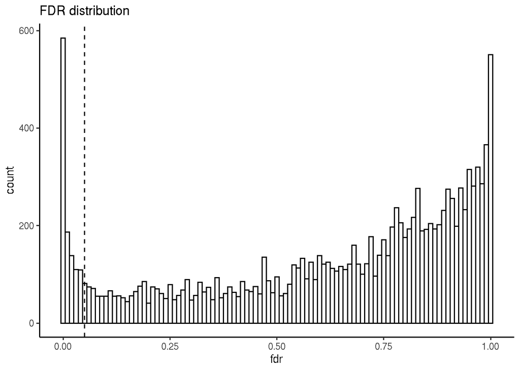

```r
df <- data.frame(
  exp="ENB",
  fdr=tt$table$FDR)
# Change colors
ggplot(df, aes(x=fdr)) +
geom_histogram(color="black", fill="white", binwidth=0.01)+
geom_vline(xintercept=0.05, linetype="dashed")+
theme_classic()+
labs(title="FDR distribution")
```

## MA plot

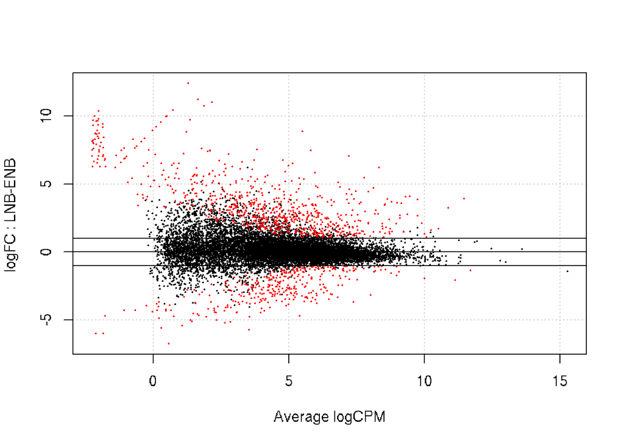

```r
deg<-rownames(tt)[tt$table$FDR <.05 &
                  abs(tt$table$logFC )>1 ]
plotSmear(y, de.tags=deg)
abline(h=c(-1,0,1))
```

## Vulcano plot (casi el último esfuerzo)

```r
ttable <-tt$table
dim(ttable)
```

```
## [1] 13327     4
```

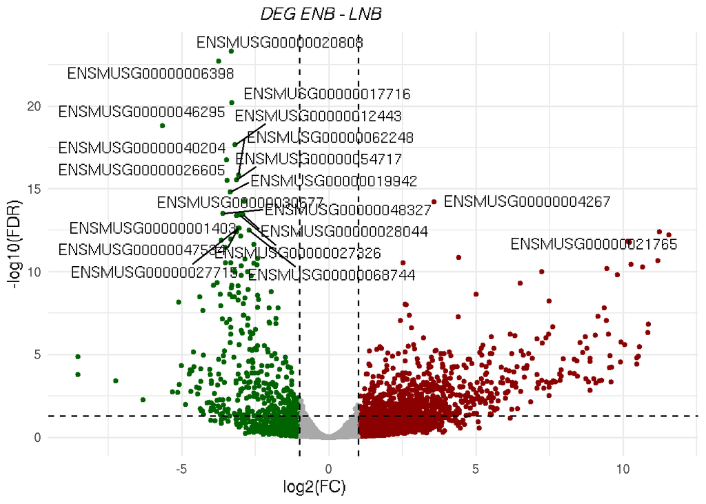

```r
tt10 <- topTags(de, n=20)

ttable$gene_color <- rep("grey", nrow(ttable))
ttable$gene_color[ttable$logFC>1] <-"red"
ttable$gene_color[ttable$logFC< (-1)]<-"green"
ttable$imp_genes<-NA

ii <- match(rownames(tt10), rownames(ttable))
ttable$imp_genes[ii]<-rownames(ttable)[ii]

ggplot(ttable, aes(x=logFC, y=-log10(FDR))) +
  geom_point(aes(col=gene_color), cex= 1.2) +
  scale_color_manual(values=c("dark green","dark grey", "dark red")) +
  labs(title="DEG ENB - LNB", x="log2(FC)", y="-log10(FDR)") +
  geom_vline(xintercept= c(-1, 1), colour= 'black', linetype= 'dashed') +
  geom_hline(yintercept= 1.30103, colour= 'black', linetype= 'dashed') +
  theme_minimal()+
  theme(legend.position = "none",
        plot.title = element_text(size = 12, face="italic", hjust=0.4),
        axis.title.x = element_text(color = "black", size=12, hjust = 0.4),
        axis.title.y = element_text(size =12, hjust = 0.5)) +
  geom_text_repel(data=ttable,
                  aes(x=logFC, y=-log10(FDR)),
                  label =ttable$imp_genes,
                  box.padding = unit(0.25, "lines"),
                  hjust =1,
                  max.overlaps = 50)
```

Exportamos los resultados en formato tabular, para futuros análisis:

```r
write.csv(tt$table, file="LNB_edgeR.csv")
tt500 <- topTags(de, n =500)
write.csv(tt500$table, file="top500_LNB_edgeR.csv")
```

## Un poquito más…

- Cambiamos el ensembl ID por el symbol. Vamos a usar los paquetes del paradigma: **org.XX.eg.db**
- Son muy prácticos para trabajar con Bioconductor

```r
MmuENS <- toTable(org.Mm.egENSEMBL2EG); head(MmuENS)
```

```
##   gene_id         ensembl_id
## 1   11287 ENSMUSG00000030359
## 2   11298 ENSMUSG00000020804
## 3   11302 ENSMUSG00000025375
## 4   11303 ENSMUSG00000015243
## 5   11304 ENSMUSG00000028125
## 6   11305 ENSMUSG00000026944
```

```r
MmuSYMBOL <- toTable(org.Mm.egSYMBOL); head(MmuSYMBOL)
```

```
##   gene_id symbol
## 1   11287    Pzp
## 2   11298  Aanat
## 3   11302   Aatk
## 4   11303  Abca1
## 5   11304  Abca4
## 6   11305  Abca2
```

- Agregamos Entrez Id:

```r
gi <- match(rownames(ttable), MmuENS$ensembl_id)
length(which(is.na(gi)))
```

```
## [1] 797
```

```r
ttable$ensemble_id <- rownames(ttable)
ttable$EntrezId <- MmuENS$gene_id[gi]
```

- Y symbol a nuestras tablas:

```r
si <- match(ttable$EntrezId, MmuSYMBOL$gene_id)
length(which(is.na(si)))
```

```
## [1] 797
```

```r
ttable$Symbol <- MmuSYMBOL$symbol[si]
head(ttable)
```

```
##                        logFC   logCPM       PValue          FDR gene_color
## ENSMUSG00000020808 -3.307172 6.397367 3.453675e-28 4.602713e-24      green
## ENSMUSG00000006398 -3.750490 7.016683 2.781374e-27 1.853368e-23      green
## ENSMUSG00000017716 -3.289403 6.450697 1.398545e-24 6.212803e-21      green
## ENSMUSG00000046295 -5.658824 5.426985 4.595531e-23 1.531116e-19      green
## ENSMUSG00000012443 -3.185382 6.769140 8.060529e-22 2.148453e-18      green
## ENSMUSG00000040204 -3.477840 6.850909 7.861722e-21 1.746220e-17      green
##                             imp_genes        ensemble_id EntrezId Symbol
## ENSMUSG00000020808 ENSMUSG00000020808 ENSMUSG00000020808   109212 Pimreg
## ENSMUSG00000006398 ENSMUSG00000006398 ENSMUSG00000006398   107995  Cdc20
## ENSMUSG00000017716 ENSMUSG00000017716 ENSMUSG00000017716    11799  Birc5
## ENSMUSG00000046295 ENSMUSG00000046295 ENSMUSG00000046295   234396 Ankle1
## ENSMUSG00000012443 ENSMUSG00000012443 ENSMUSG00000012443    16551  Kif11
## ENSMUSG00000040204 ENSMUSG00000040204 ENSMUSG00000040204    68026  Pclaf
```

- Ahora podemos repetir el vulcano plot con el **symbol** como etiqueta:

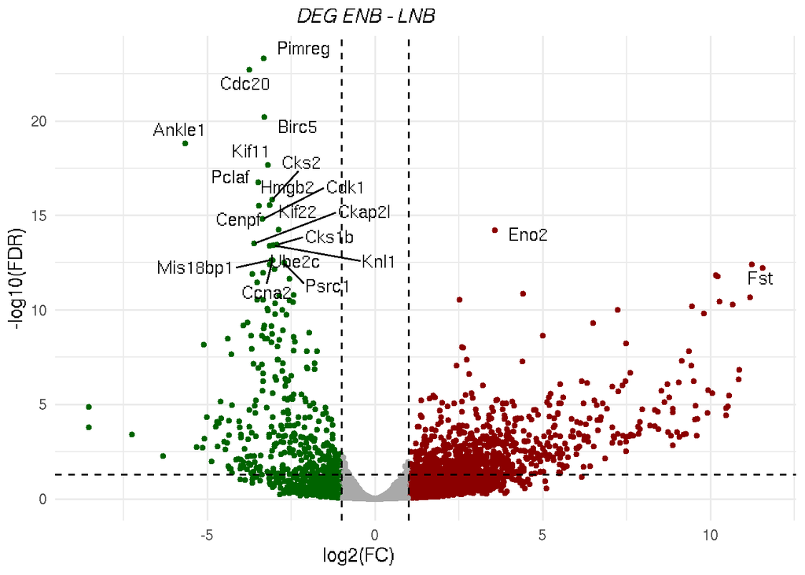

```r
ii <- match(rownames(tt10), rownames(ttable))
ttable$imp_genes[ii]<-ttable$Symbol[ii]

ggplot(ttable, aes(x=logFC, y=-log10(FDR))) +
  geom_point(aes(col=gene_color), cex= 1.2) +
  scale_color_manual(values=c("dark green","dark grey", "dark red")) +
  labs(title="DEG ENB - LNB", x="log2(FC)", y="-log10(FDR)") +
  geom_vline(xintercept= c(-1, 1), colour= 'black', linetype= 'dashed') +
  geom_hline(yintercept= 1.30103, colour= 'black', linetype= 'dashed') +
  theme_minimal()+
  theme(legend.position = "none",
        plot.title = element_text(size = 12, face="italic", hjust=0.4),
        axis.title.x = element_text(color = "black", size=12, hjust = 0.4),
        axis.title.y = element_text(size =12, hjust = 0.5)) +
  geom_text_repel(data=ttable,
                  aes(x=logFC, y=-log10(FDR)),
                  label =ttable$imp_genes,
                  box.padding = unit(0.25, "lines"),
                  hjust =1,
                  max.overlaps = 50)
```

## Gene Ontology

Podemos analizar enriquecimientos ontológicos de una forma muy sencilla:

- Primero hay que agregar EntrezID al objeto **de**:

```r
entrezi <- match(rownames(de), MmuENS$ensembl_id)
length(which(is.na(entrezi)))
```

```
## [1] 797
```

```r
de$ensemble_id <- rownames(de)
de$EntrezId <- MmuENS$gene_id[entrezi]
```

- Ahora vamos testeando, con diferentes opciones la lista de genes **de**
- Procesos Biológicos:

```r
go <- goana(de, species = "Mm", geneid=de$EntrezId)
topBPUp<-topGO(go, ont="BP", n=30, truncate=30, sort = "Up")
head(topBPUp)# enriquecimiento sobreexpresados
```

```
##                                      Term Ont    N  Up Down         P.Up
## GO:0006811                  ion transport  BP  958 144    7 4.137445e-25
## GO:0007154             cell communication  BP 3446 339   78 3.374315e-24
## GO:0023052                      signaling  BP 3402 335   79 6.883208e-24
## GO:0065008 regulation of biological qu...  BP 2647 279   42 2.121392e-23
## GO:0050896           response to stimulus  BP 4843 424  159 2.053999e-21
## GO:0007267            cell-cell signaling  BP 1057 144   17 7.442583e-21
##                P.Down
## GO:0006811 0.99999987
## GO:0007154 0.99890169
## GO:0023052 0.99734125
## GO:0065008 0.99999988
## GO:0050896 0.06775172
## GO:0007267 0.99893925
```

```r
topBPDown<-topGO(go, ont="BP", n=30, truncate=30, sort = "Down")
head(topBPDown)
```

```
##                                  Term Ont    N Up Down      P.Up       P.Down
## GO:0007049                 cell cycle  BP 1324 40  188 1.0000000 2.919989e-86
## GO:0000278         mitotic cell cycle  BP  721 23  140 0.9999265 4.135527e-79
## GO:0022402         cell cycle process  BP  934 30  154 0.9999914 2.567920e-77
## GO:1903047 mitotic cell cycle process  BP  596 17  126 0.9999491 4.996146e-75
## GO:0051301              cell division  BP  500 12  108 0.9999810 1.907835e-64
## GO:0007059     chromosome segregation  BP  274  3   82 0.9999958 1.856786e-60
```

- Función molecular (MF)

```r
topMF<-topGO(go, ont="MF", n=30, truncate=30)
head(topMF)
```

```
##                                      Term Ont   N Up Down         P.Up
## GO:0060089 molecular transducer activi...  MF 367 75    5 6.759538e-21
## GO:0038023    signaling receptor activity  MF 367 75    5 6.759538e-21
## GO:0015318 inorganic molecular entity ...  MF 469 80    4 3.014097e-17
## GO:0005509            calcium ion binding  MF 341 65    6 1.270428e-16
## GO:0004888 transmembrane signaling rec...  MF 284 58    4 2.319354e-16
## GO:0022857 transmembrane transporter a...  MF 600 89    4 3.403408e-15
##               P.Down
## GO:0060089 0.9865463
## GO:0038023 0.9865463
## GO:0015318 0.9996531
## GO:0005509 0.9445580
## GO:0004888 0.9724532
## GO:0022857 0.9999887
```

- Componentes celulares (CC)

```r
topCC<-topGO(go, ont="CC", n=30, truncate=30)
head(topCC)
```

```
##                                      Term Ont    N  Up Down         P.Up
## GO:0031224 intrinsic component of memb...  CC 2806 367   20 2.072405e-57
## GO:0016021 integral component of membr...  CC 2718 357   20 9.197083e-56
## GO:0005694                     chromosome  CC 1091  14  138 1.000000e+00
## GO:0016020                       membrane  CC 5153 511   82 7.362712e-48
## GO:0000775 chromosome, centromeric reg...  CC  184   1   60 9.999923e-01
## GO:0043232 intracellular non-membrane-...  CC 3475  99  233 1.000000e+00
##                  P.Down
## GO:0031224 1.000000e+00
## GO:0016021 1.000000e+00
## GO:0005694 3.005875e-53
## GO:0016020 1.000000e+00
## GO:0000775 1.931473e-46
## GO:0043232 1.690649e-45
```

- Vías metabólicas usando KEGG:

```r
keg <- kegga(de, species="Mm",  geneid=de$EntrezId)
topKEGG(keg)
```

```
##                                               Pathway    N  Up Down
## path:mmu04110                              Cell cycle  116   2   36
## path:mmu03030                         DNA replication   33   0   20
## path:mmu04080 Neuroactive ligand-receptor interaction   95  25    1
## path:mmu01100                      Metabolic pathways 1111 115   15
## path:mmu03460                  Fanconi anemia pathway   49   0   11
## path:mmu04114                          Oocyte meiosis  101   7   15
## path:mmu04914 Progesterone-mediated oocyte maturation   80   2   13
## path:mmu04115                   p53 signaling pathway   60   4   11
## path:mmu03410                    Base excision repair   29   0    8
## path:mmu03440                Homologous recombination   39   0    9
## path:mmu04020               Calcium signaling pathway  124  23    0
## path:mmu04727                       GABAergic synapse   67  16    0
## path:mmu03430                         Mismatch repair   22   0    7
## path:mmu04911                       Insulin secretion   60  15    0
## path:mmu04024                  cAMP signaling pathway  137  24    0
## path:mmu03420              Nucleotide excision repair   42   0    9
## path:mmu04724                   Glutamatergic synapse   95  19    0
## path:mmu04512                ECM-receptor interaction   43  12    1
## path:mmu05200                      Pathways in cancer  370  45   13
## path:mmu04218                     Cellular senescence  132   7   15
##                       P.Up       P.Down
## path:mmu04110 9.947611e-01 3.848581e-27
## path:mmu03030 1.000000e+00 8.138497e-23
## path:mmu04080 3.408781e-10 9.448988e-01
## path:mmu01100 1.177989e-08 9.999335e-01
## path:mmu03460 1.000000e+00 1.568700e-07
## path:mmu04114 4.309761e-01 3.004773e-07
## path:mmu04914 9.618688e-01 6.462858e-07
## path:mmu04115 5.103780e-01 1.373055e-06
## path:mmu03410 1.000000e+00 1.481120e-06
## path:mmu03440 1.000000e+00 1.678766e-06
## path:mmu04020 1.717205e-06 1.000000e+00
## path:mmu04727 2.147971e-06 1.000000e+00
## path:mmu03430 1.000000e+00 2.356760e-06
## path:mmu04911 2.402431e-06 1.000000e+00
## path:mmu04024 2.956951e-06 1.000000e+00
## path:mmu03420 1.000000e+00 3.262504e-06
## path:mmu04724 4.289290e-06 1.000000e+00
## path:mmu04512 7.167706e-06 7.299682e-01
## path:mmu05200 8.987111e-06 3.165741e-01
## path:mmu04218 7.122344e-01 9.362690e-06
```